# Informações dos dados

Para esse estudo de caso são analisados dados de operação de uma coluna FCC (Fluid Catalytic Cracking) presente em uma refinaria brasileira real. Os conjuntos de dados fornecidos para o desenvolvimento desse estudo de caso são relativos ao monitoramento de uma falha de agarramento da válvula de controle de nível de catalisadores desativados que fluem do reator para o regenerador da coluna FCC.

Dado que o objetivo desse estudo de caso é analisar a performance de um método baseado em modelo de rede neural recorrente bayesiana na detecção específica da falha de agarramento da válvula de controle de nível da coluna FCC, três conjuntos de dados foram fornecidos: um conjunto de dados contendo apenas dados de operação normal da coluna, dois conjuntos de dados contendo dados de operação da coluna em períodos em que foram detectadas por engenheiros falhas de agarramento em sua válvula de controle de nível. Durante o desenvolvimento do estudo de caso, o conjunto de dados de operação normal será utilizado para treinamento dos modelos de detecção, enquanto que os outros dois conjuntos de dados serão utilizados para teste dos modelos.

### Conjunto de dados de treinamento

**Nome do arquivo:** CONV_DATA_SET_5_REV_0.csv

**Período de monitoramento:** 01/06/2021 a 15/06/2021 (15 dias)

**Frequência da amostragem:** 1 minuto

**Descrição:** Dados de operação normal da coluna FCC.

### Conjunto de dados de teste 1

**Nome do arquivo:** CONV_DATA_SET_2_REV_1.csv

**Período de monitoramento:** 15/05/2011 a 25/05/2011 (11 dias)

**Frequência da amostragem:** 1 minuto

**Descrição:** Dados de operação da coluna FCC em um período em que foram detectadas falhas de agarramento em sua válvula de controle de nível.

### Conjunto de dados de teste 2

**Nome do arquivo:** CONV_DATA_SET_3_REV_1.csv

**Período de monitoramento:** 01/04/2012 a 10/04/2012 (10 dias)

**Frequência da amostragem:** 1 minuto

**Descrição:** Dados de operação da coluna FCC em um período em que foram detectadas falhas de agarramento em sua válvula de controle de nível.

### Variáveis

Em cada um dos conjuntos de dados são disponibilizados os *timestamps* de coleta dos dados e os valores de 17 variáveis de processo da coluna FCC monitoradas para detecção falha de agarramento da válvula de controle de nível.

- **timestamp**: dia e hora da coleta do dado (dd/mm/yyyy hh:mm)
- **x<sup>1</sup>**: nível de catalisadores no vaso superior (%)
- **x<sup>2</sup>**: nível de catalisadores no vaso superior - set point (%)
- **x<sup>3</sup>**: nível de catalisadores no vaso superior - variável manipulada (%)
- **x<sup>4</sup>**: feedback output (%)
- **x<sup>5</sup>**: diferença de pressão na válvula do regenerador (kgf/cm<sup>2</sup>g)
- **x<sup>6</sup>**: diferença de pressão na válvula do regenerador - set point (kgf/cm<sup>2</sup>g)
- **x<sup>7</sup>**: diferença de pressão na válvula do regenerador - variável manipulada (%)
- **x<sup>8</sup>**: alimentação de gasóleo pesado (GOP) (m<sup>3</sup>/dia)
- **x<sup>9</sup>**: alimentação de nafta (m<sup>3</sup>/dia)
- **x<sup>10</sup>**: presssão do regenerador (kgf/cm<sup>2</sup>g)
- **x<sup>11</sup>**: pressão do reator (kgf/cm<sup>2</sup>g)
- **x<sup>12</sup>**: temperatura de reação (°C)
- **x<sup>13</sup>**: temperatura de reação - set point (°C)
- **x<sup>14</sup>**: temperatura de reação - variável manipulada (%)
- **x<sup>15</sup>**: temperatura da alimentação (°C)
- **x<sup>16</sup>**: fluxo de ar no regenerador (kNm<sup>3</sup>/dia)
- **x<sup>17</sup>**: circulação de catalisadores (ton/min)

# Exploração dos dados

### Setup

```python
import pandas as pd
import matplotlib.pyplot as plt
import seaborn as sns

# plot parameters
plt.rcParams["figure.figsize"] = [20, 8]
```

### Análise do formato dos dados

**Conjundo de dados de treinamento**

```python
df_train = pd.read_csv("datasets/original/CONV_DATA_SET_5_REV_0.csv", delimiter=";", header=0, skiprows=[1, 2])
df_train.columns = ["timestamp", "x1", "x2", "x3", "x4", "x5", "x6", "x7", "x8", "x9", "x10", "x11", "x12", "x13", "x14", "x15", "x16", "x17"]
df_train.head()
```

|  | timestamp | x1 | x2 | x3 | x4 | x5 | x6 | x7 | x8 | x9 | x10 | x11 | x12 | x13 | x14 | x15 | x16 | x17 |
| --- | --- | --- | --- | --- | --- | --- | --- | --- | --- | --- | --- | --- | --- | --- | --- | --- | --- | --- |
| 0 | 01/06/2021 00:00 | 4.820679 | 5.008938 | 27.880791 | 28.154675 | 0.956431 | 0.55 | 100 | 8539.384766 | 1370.217407 | 1.731934 | 1.215717 | 542.562378 | 542.937134 | 50.184551 | 333.826599 | 3999.373047 | 39.244167 |
| 1 | 01/06/2021 00:01 | 4.820952 | 5.008938 | 28.111809 | 28.127951 | 0.951423 | 0.55 | 100 | 8511.902344 | 1368.905762 | 1.731030 | 1.212713 | 542.260864 | 542.937134 | 50.396320 | 333.844940 | 3994.509277 | 39.245514 |
| 2 | 01/06/2021 00:02 | 4.821226 | 5.008938 | 28.071926 | 28.101227 | 0.961223 | 0.55 | 100 | 8483.062500 | 1369.733887 | 1.731332 | 1.215683 | 542.770996 | 542.937134 | 50.418854 | 333.552643 | 4005.993164 | 39.246860 |
| 3 | 01/06/2021 00:03 | 4.821499 | 5.008938 | 27.736803 | 28.074503 | 0.951415 | 0.55 | 100 | 8445.349609 | 1368.666870 | 1.730829 | 1.219262 | 542.977905 | 542.937134 | 50.365505 | 333.465454 | 3995.365967 | 39.248207 |
| 4 | 01/06/2021 00:04 | 4.821773 | 5.008938 | 27.485134 | 28.047777 | 0.951445 | 0.55 | 100 | 8418.049805 | 1368.864868 | 1.731332 | 1.218987 | 542.794250 | 542.945679 | 50.420170 | 333.637848 | 4000.796143 | 39.249554 |

```python
df_train.info()
```

```
<class 'pandas.core.frame.DataFrame'>
RangeIndex: 20161 entries, 0 to 20160
Data columns (total 18 columns):
 #   Column     Non-Null Count  Dtype
---  ------     --------------  -----
 0   timestamp  20161 non-null  object
 1   x1         20161 non-null  float64
 2   x2         20161 non-null  float64
 3   x3         20161 non-null  float64
 4   x4         20161 non-null  float64
 5   x5         20161 non-null  float64
 6   x6         20161 non-null  float64
 7   x7         20161 non-null  int64
 8   x8         20161 non-null  float64
 9   x9         20161 non-null  float64
 10  x10        20161 non-null  float64
 11  x11        20161 non-null  float64
 12  x12        20161 non-null  float64
 13  x13        20161 non-null  float64
 14  x14        20161 non-null  float64
 15  x15        20161 non-null  float64
 16  x16        20161 non-null  float64
 17  x17        20161 non-null  float64
dtypes: float64(16), int64(1), object(1)
memory usage: 2.8+ MB
```

Observações:

- timestamps precisam ser convertidos para o formato *datetime*
- x7 precisa está no formato *int64* e precisa ser convertido para o formato *float64*
- não há dados vazios em nenhuma das variáveis

**Conjunto de dados de teste 1**

```python
df_test1 = pd.read_csv("datasets/original/CONV_DATA_SET_2_REV_1.csv", delimiter=";", header=0, skiprows=[1, 2])
df_test1.columns = ["timestamp", "x1", "x2", "x3", "x4", "x5", "x6", "x7", "x8", "x9", "x10", "x11", "x12", "x13", "x14", "x15", "x16", "x17"]
df_test1.head()
```

|  | timestamp | x1 | x2 | x3 | x4 | x5 | x6 | x7 | x8 | x9 | x10 | x11 | x12 | x13 | x14 | x15 | x16 | x17 |
| --- | --- | --- | --- | --- | --- | --- | --- | --- | --- | --- | --- | --- | --- | --- | --- | --- | --- | --- |
| 0 | 15/05/2011 00:00 | 4.774647 | 5 | 41.235447 | 41.054737 | 0.711813 | 0.4 | 100 | 9113.216797 | 1001.702148 | 1.620825 | 1.281797 | 534.477234 | 534.429382 | 48.674740 | 250.269608 | 4518.571289 | 31.947456 |
| 1 | 15/05/2011 00:01 | 4.775790 | 5 | 41.030991 | 41.056587 | 0.706777 | 0.4 | 100 | 9088.170898 | 999.734985 | 1.622454 | 1.281679 | 534.487915 | 534.448791 | 48.673882 | 250.622223 | 4507.051758 | 31.944284 |
| 2 | 15/05/2011 00:02 | 4.776933 | 5 | 41.322945 | 41.058437 | 0.712554 | 0.4 | 100 | 9088.625000 | 999.797058 | 1.621738 | 1.281561 | 534.435059 | 534.463928 | 48.700249 | 250.930069 | 4528.894043 | 31.941114 |
| 3 | 15/05/2011 00:03 | 4.778075 | 5 | 40.994583 | 41.060284 | 0.717025 | 0.4 | 100 | 9159.108398 | 1001.367004 | 1.620782 | 1.281442 | 534.640808 | 534.490112 | 48.613491 | 251.214172 | 4543.851074 | 31.937942 |
| 4 | 15/05/2011 00:04 | 4.779218 | 5 | 41.411636 | 41.062134 | 0.693954 | 0.4 | 100 | 9169.337891 | 1003.351440 | 1.619820 | 1.281324 | 534.741455 | 534.510681 | 48.550117 | 251.337784 | 4528.670898 | 31.934771 |

```python
df_test1.info()
```

```
<class 'pandas.core.frame.DataFrame'>
RangeIndex: 14401 entries, 0 to 14400
Data columns (total 18 columns):
 #   Column     Non-Null Count  Dtype
---  ------     --------------  -----
 0   timestamp  14401 non-null  object
 1   x1         14401 non-null  float64
 2   x2         14401 non-null  int64
 3   x3         14401 non-null  float64
 4   x4         14401 non-null  float64
 5   x5         14401 non-null  float64
 6   x6         14401 non-null  float64
 7   x7         14401 non-null  int64
 8   x8         14401 non-null  float64
 9   x9         14401 non-null  float64
 10  x10        14401 non-null  float64
 11  x11        14401 non-null  float64
 12  x12        14401 non-null  float64
 13  x13        14401 non-null  float64
 14  x14        14401 non-null  float64
 15  x15        14401 non-null  float64
 16  x16        14401 non-null  float64
 17  x17        14401 non-null  float64
dtypes: float64(15), int64(2), object(1)
memory usage: 2.0+ MB
```

Observações:

- timestamps precisam ser convertidos para o formato *datetime*
- x2 precisa está no formato *int64* e precisa ser convertido para o formato *float64*
- x7 precisa está no formato *int64* e precisa ser convertido para o formato *float64*
- não há dados vazios em nenhuma das variáveis

**Conjunto de dados de teste 2**

```python
df_test2 = pd.read_csv("datasets/original/CONV_DATA_SET_3_REV_1.csv", delimiter=";", header=0, skiprows=[1, 2])
df_test2.columns = ["timestamp", "x1", "x2", "x3", "x4", "x5", "x6", "x7", "x8", "x9", "x10", "x11", "x12", "x13", "x14", "x15", "x16", "x17"]
df_test2.head()
```

|  | timestamp | x1 | x2 | x3 | x4 | x5 | x6 | x7 | x8 | x9 | x10 | x11 | x12 | x13 | x14 | x15 | x16 | x17 |
| --- | --- | --- | --- | --- | --- | --- | --- | --- | --- | --- | --- | --- | --- | --- | --- | --- | --- | --- |
| 0 | 01/04/2012 00:00 | 4.241906 | 5.038079 | 41.330364 | 41.884705 | 0.785922 | 0.4 | 100 | 9203.445313 | 1000.187256 | 1.510093 | 1.188423 | 538.560120 | 538.563660 | 44.496689 | 273.757263 | 4549.782227 | 31.182013 |
| 1 | 01/04/2012 00:01 | 4.282500 | 5.038079 | 40.937592 | 41.895687 | 0.800040 | 0.4 | 100 | 9206.594727 | 1000.715393 | 1.510778 | 1.188279 | 538.491943 | 538.573059 | 44.499447 | 273.931152 | 4549.725586 | 31.180729 |
| 2 | 01/04/2012 00:02 | 4.294424 | 5.038079 | 41.556946 | 41.906670 | 0.761630 | 0.4 | 100 | 9209.744141 | 998.984009 | 1.510941 | 1.188135 | 538.887451 | 538.582459 | 44.474369 | 274.256867 | 4549.668457 | 31.179445 |
| 3 | 01/04/2012 00:03 | 4.306348 | 5.038079 | 41.592968 | 41.917652 | 0.757114 | 0.4 | 100 | 9212.893555 | 998.743164 | 1.510920 | 1.187991 | 538.784302 | 538.588379 | 44.415276 | 274.679748 | 4549.611328 | 31.178162 |
| 4 | 01/04/2012 00:04 | 4.318272 | 5.038079 | 41.646286 | 41.928631 | 0.756584 | 0.4 | 100 | 9216.043945 | 999.936157 | 1.511907 | 1.187846 | 538.687256 | 538.590576 | 44.367886 | 274.962402 | 4549.532715 | 31.176878 |

```python
df_test2.info()
```

```
<class 'pandas.core.frame.DataFrame'>
RangeIndex: 12961 entries, 0 to 12960
Data columns (total 18 columns):
 #   Column     Non-Null Count  Dtype
---  ------     --------------  -----
 0   timestamp  12961 non-null  object
 1   x1         12961 non-null  float64
 2   x2         12961 non-null  float64
 3   x3         12961 non-null  float64
 4   x4         12961 non-null  float64
 5   x5         12961 non-null  float64
 6   x6         12961 non-null  float64
 7   x7         12961 non-null  int64
 8   x8         12961 non-null  float64
 9   x9         12961 non-null  float64
 10  x10        12961 non-null  float64
 11  x11        12961 non-null  float64
 12  x12        12961 non-null  float64
 13  x13        12961 non-null  float64
 14  x14        12961 non-null  float64
 15  x15        12961 non-null  float64
 16  x16        12961 non-null  float64
 17  x17        12961 non-null  float64
dtypes: float64(16), int64(1), object(1)
memory usage: 1.8+ MB
```

Observações:

- timestamps precisam ser convertidos para o formato *datetime*
- x7 precisa está no formato *int64* e precisa ser convertido para o formato *float64*
- não há dados vazios em nenhuma das variáveis

#### Correção do formato dos dados

**Conjunto de dados de treinamento**

- coversão dos timestamps para o formato *datetime*
- conversão de x7 para formato *float64*

```python
df_train["timestamp"] = pd.to_datetime(df_train["timestamp"], format='%d/%m/%Y %H:%M' )
df_train["x7"] = df_train["x7"].astype(float)
df_train.info()
```

```
<class 'pandas.core.frame.DataFrame'>
RangeIndex: 20161 entries, 0 to 20160
Data columns (total 18 columns):
 #   Column     Non-Null Count  Dtype
---  ------     --------------  -----
 0   timestamp  20161 non-null  datetime64[ns]
 1   x1         20161 non-null  float64
 2   x2         20161 non-null  float64
 3   x3         20161 non-null  float64
 4   x4         20161 non-null  float64
 5   x5         20161 non-null  float64
 6   x6         20161 non-null  float64
 7   x7         20161 non-null  float64
 8   x8         20161 non-null  float64
 9   x9         20161 non-null  float64
 10  x10        20161 non-null  float64
 11  x11        20161 non-null  float64
 12  x12        20161 non-null  float64
 13  x13        20161 non-null  float64
 14  x14        20161 non-null  float64
 15  x15        20161 non-null  float64
 16  x16        20161 non-null  float64
 17  x17        20161 non-null  float64
dtypes: datetime64[ns](1), float64(17)
memory usage: 2.8 MB
```

**Conjunto de dados de teste 1**

- coversão dos timestamps para o formato *datetime*
- conversão de x2 para formato *float64*
- conversão de x7 para formato *float64*

```python
df_test1["timestamp"] = pd.to_datetime(df_test1["timestamp"], format='%d/%m/%Y %H:%M')
df_test1["x2"] = df_test1["x2"].astype(float)
df_test1["x7"] = df_test1["x7"].astype(float)
df_test1.info()
```

```
<class 'pandas.core.frame.DataFrame'>
RangeIndex: 14401 entries, 0 to 14400
Data columns (total 18 columns):
 #   Column     Non-Null Count  Dtype
---  ------     --------------  -----
 0   timestamp  14401 non-null  datetime64[ns]
 1   x1         14401 non-null  float64
 2   x2         14401 non-null  float64
 3   x3         14401 non-null  float64
 4   x4         14401 non-null  float64
 5   x5         14401 non-null  float64
 6   x6         14401 non-null  float64
 7   x7         14401 non-null  float64
 8   x8         14401 non-null  float64
 9   x9         14401 non-null  float64
 10  x10        14401 non-null  float64
 11  x11        14401 non-null  float64
 12  x12        14401 non-null  float64
 13  x13        14401 non-null  float64
 14  x14        14401 non-null  float64
 15  x15        14401 non-null  float64
 16  x16        14401 non-null  float64
 17  x17        14401 non-null  float64
dtypes: datetime64[ns](1), float64(17)
memory usage: 2.0 MB
```

**Conjunto de dados de teste 2**

- coversão dos timestamps para o formato *datetime*
- conversão de x7 para formato *float64*

```python
df_test2["timestamp"] = pd.to_datetime(df_test2["timestamp"], format='%d/%m/%Y %H:%M')
df_test2["x7"] = df_test2["x7"].astype(float)
df_test1.info()
```

[output not shown]

### Visualização dos dados

Conversando com engenheiros da refinaria onde se encontra a coluna FCC analisada, de acordo com eles, a variável x1 é a variável mais afetada pela falha de agarramento na válvula de controle de nível da coluna. Por essa razão, a variável x1 será a primeira a ser visualizada e analisada.

**Visualização da variável x1 - Conjunto de dados de treinamento**

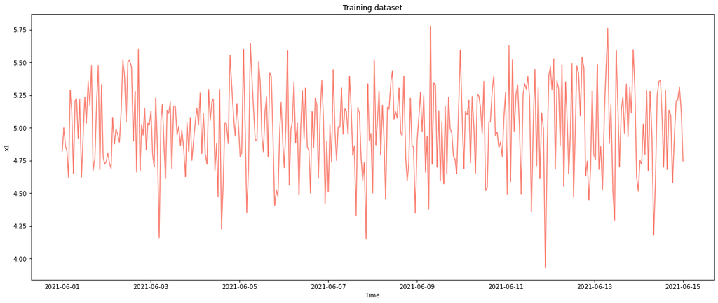

```python
plt.plot(df_train['timestamp'], df_train['x1'], label='Training Dataset', color='salmon')
plt.title('Training dataset')
plt.ylabel('x1')
plt.xlabel('Time')
plt.show()
```

**Visualização da variável x1 - Conjunto de dados de teste 1**

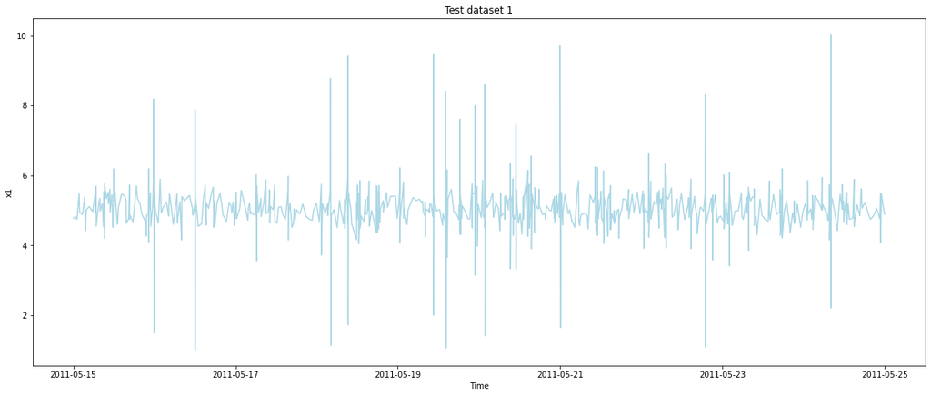

```python
plt.plot(df_test1['timestamp'], df_test1['x1'], label='Test dataset 1', color='lightblue')
plt.title('Test dataset 1')
plt.ylabel('x1')
plt.xlabel('Time')
plt.show()
```

**Visualização da variável x1 - Conjunto de dados de teste 2**

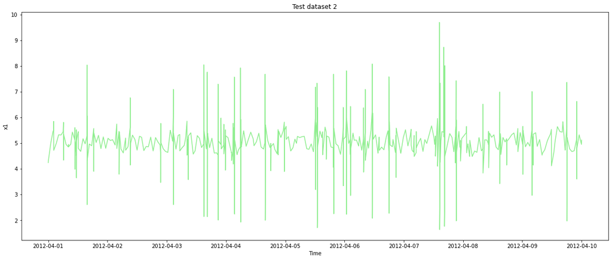

```python
plt.plot(df_test2['timestamp'], df_test2['x1'], label='Test dataset 2', color='lightgreen')
plt.title('Test dataset 2')
plt.ylabel('x1')
plt.xlabel('Time')
plt.show()
```

**Comparação**

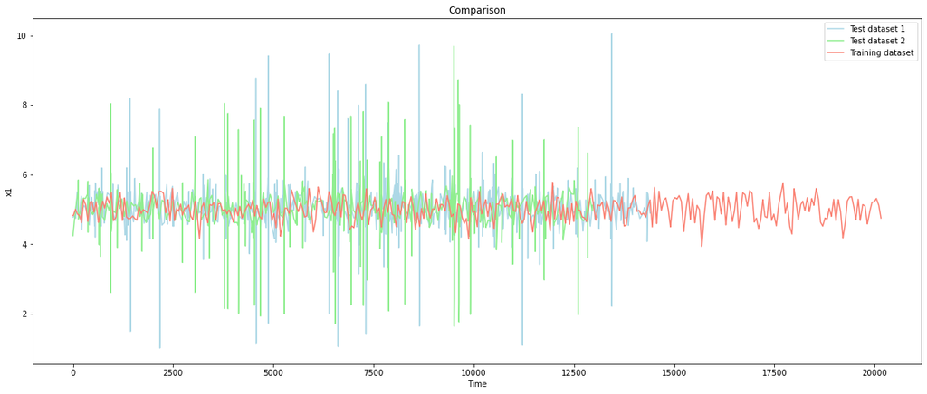

```python
plt.plot(range(len(df_test1['x1'])), df_test1['x1'], label='Test dataset 1', color='lightblue')
plt.plot(range(len(df_test2['x1'])), df_test2['x1'], label='Test dataset 2', color='lightgreen')
plt.plot(range(len(df_train['x1'])), df_train['x1'], label='Training dataset', color='salmon')
plt.title('Comparison')
plt.ylabel('x1')
plt.xlabel('Time')
plt.legend()
plt.show()
```

Observações:

- Comparado ao dataset de treinamento, nota-se que os datasets de teste 1 e 2 apresentam picos na série temporal da variável x1 que, de acordo com os engenheiros da refinaria, caracterizam falhas na válvula de controle de nível da coluna FCC.
- Nota-se, portanto, que a variável x1 é uma variável que pode ser utilizada para o treinamento de modelos para detecção da falha de agarramento na válvula de controle de nível da coluna.

Sendo assim, dado a relevância da variável x1 para detecção da falha de agarramento na válvula de controle de nível da coluna FCC, em seguida será analisada a correlação da outras variáveis em relação à variável x1 para descobrir quais variáveis podem auxiliar na detecção da falha de agarramento.

**Análise de correlação - Conjunto de dados de treinamento**

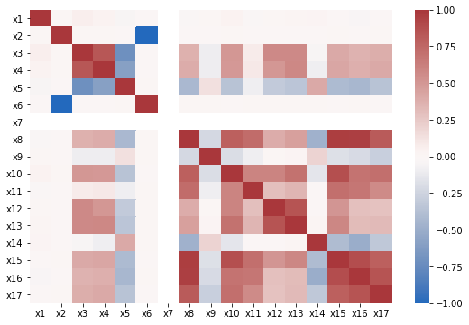

```python
plt.rcParams["figure.figsize"] = [9, 6]
df_train_corr = df_train.corr()
sns.heatmap(df_train_corr, cmap='vlag', vmin=-1, vmax=1)
plt.yticks(rotation='horizontal')
plt.show()
```

Valor de correlação das variáveis em relação à variável x1 no conjunto de dados de treinamento:

```python
df_train_corr['x1']
```

```
x1     1.000000e+00
x2     4.301248e-15
x3     6.520789e-02
x4     4.673100e-02
x5    -4.180267e-02
x6    -4.541371e-15
x7              NaN
x8    -2.349184e-02
x9     1.052263e-02
x10    4.519971e-02
x11   -2.752130e-02
x12    4.945637e-03
x13    1.625256e-02
x14    2.982488e-02
x15   -5.139488e-03
x16   -3.822966e-02
x17   -2.517815e-03
Name: x1, dtype: float64
```

**Análise de correlação - Conjunto de dados de teste 1**

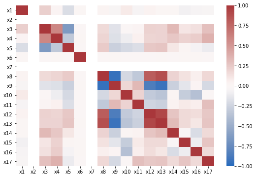

```python
df_test1_corr = df_test1.corr()
sns.heatmap(df_test1_corr, cmap='vlag', vmin=-1, vmax=1)
plt.yticks(rotation='horizontal')
plt.show()
```

Valor de correlação das variáveis em relação à variável x1 no conjunto de dados de teste 1:

```python
df_test1_corr['x1']
```

```
x1     1.000000e+00
x2              NaN
x3     2.224085e-01
x4     2.666857e-02
x5    -1.896814e-01
x6     8.511127e-14
x7              NaN
x8     3.658228e-02
x9    -3.974273e-02
x10    9.070665e-02
x11   -4.834312e-02
x12    4.294916e-02
x13    1.434428e-02
x14    1.084962e-02
x15   -7.043002e-02
x16   -4.785855e-02
x17   -4.360243e-02
Name: x1, dtype: float64
```

**Análise de correlação - Conjunto de dados de teste 2**

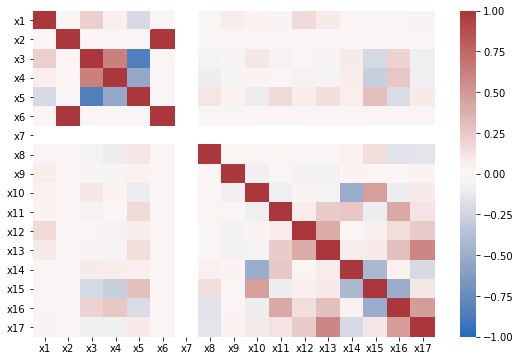

```python
df_test2_corr = df_test2.corr()
sns.heatmap(df_test2_corr, cmap='vlag', vmin=-1, vmax=1)
plt.yticks(rotation='horizontal')
plt.show()
```

Valor de correlação das variáveis em relação à variável x1 no conjunto de dados de teste 2:

```python
df_test2_corr['x1']
```

```
x1     1.000000e+00
x2     2.070396e-14
x3     2.236285e-01
x4     6.279093e-02
x5    -2.054371e-01
x6     2.060672e-14
x7              NaN
x8    -1.663109e-02
x9     7.444117e-02
x10    4.324389e-02
x11    2.857517e-02
x12    1.687801e-01
x13    8.301767e-02
x14    9.105886e-03
x15   -1.994130e-02
x16    4.577108e-03
x17    2.418307e-02
Name: x1, dtype: float64
```

Observações:

- No conjunto de dados de treinamento, nota-se que todas as variáveis possuem uma correlação quase nula em relação à variável x1.
- Já nos conjuntos de dados de teste 1 e 2, nota-se que a maioria das variáveis possuem uma correlação quase nula em relação à variável x1, com exceção das variáveis x3 e x5, as quais possuem uma correlação um pouco maior que zero.
- Desta forma, nota-se que as variáveis x3 e x5 podem possilvelmente ser utilizadas junto da variável x1 para o treinamento de modelo de detecção da falha de agarramento.

Em seguida, então, serão visualizadas as variáveis x3 e x5 nos conjuntos de dados teste em parelo à variável x1 com objetivo de analisar o comportamento dessas variáveis nos momentos de ocorrência de picos na série temporal da variável x1 que, de acordo com os engenheiros da refinaria, caracterizam falhas na válvula de controle de nível da coluna FCC.

**Visualização das variáveis x3 e x5 - Conjunto de dados de teste 1**

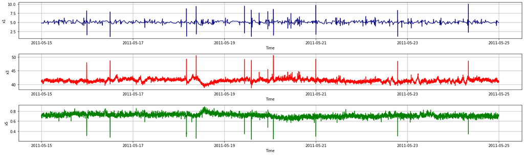

```python
column_names = ['x1', 'x3', 'x5'] # exclui coluna PERIODO
colors = ['navy', 'red', 'green']

fig, axs = plt.subplots(len(column_names), 1)

for i, name in enumerate(column_names):
    color = colors[i]
    axs[i].plot(df_test1['timestamp'], df_test1[name], color = color)
    axs[i].set_xlabel('Time')
    axs[i].set_ylabel(name)
    # axs[i].set_title(name)
    axs[i].grid(True)

fig.set_size_inches(20, 6)
fig.tight_layout()
fig.subplots_adjust(top=0.975)
plt.show()
```

**Visualização das variáveis x3 e x5 - Conjunto de dados de teste 2**

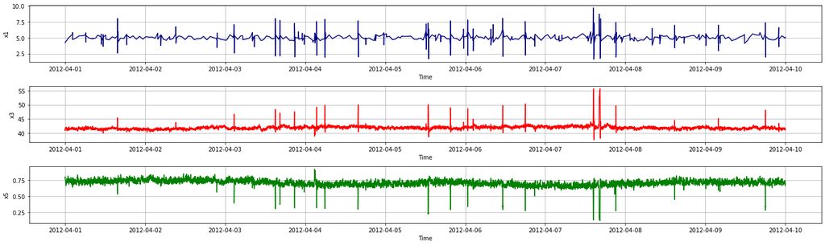

```python
fig, axs = plt.subplots(len(column_names), 1)

for i, name in enumerate(column_names):
    color = colors[i]
    axs[i].plot(df_test2['timestamp'], df_test2[name], color = color)
    axs[i].set_xlabel('Time')
    axs[i].set_ylabel(name)
    # axs[i].set_title(name)
    axs[i].grid(True)

fig.set_size_inches(20, 6)
fig.tight_layout()
fig.subplots_adjust(top=0.975)
plt.show()
```

Observações:

- Nota-se que na maioria das ocorrências de picos na série temporal da variável x1 há também ocorrências de picos nas séries temporais da variáveis x3 e x5.
- Por essa razão, possivelmente, as variáveis x3 e x5 possuem valores de correlação não nulos com relação à variável x1 nos conjuntos de dados de teste.
- Portanto, nota-se novamente que as variáveis x3 e x5 podem ser utilizadas junto da variável x1 para o treinamento de modelo de detecção da falha de agarramento.

# Visualização das falhas

De acordo com os engenheiros da coluna, as falhas de agarramento na válvula de controle de nível da coluna FCC são normalmente detectadas manualmente pelos engenheiros da coluna por meio do monitoramento visual das séries temporais das variáveis de monitoramento da coluna FCC, ficando atento principalmente a picos na série temporal da variável x1.

Sendo assim, os dados coletados nos momentos de ocorrência de falhas de agarramento na válvula de controle de nível da coluna FCC detectadas por seus engenheiros nos períodos do conjunto de dados de teste 1 e conjunto de dados de teste 2 são disponibilisados em dois conjuntos de dados. No conjunto de dados de treinamento não há ocorrências de falhas.

### Falhas do conjunto de dados de teste 1

**Nome do arquivo:** CONV_DATA_SET_2_REV_1_FAULTS.csv

**Descrição:** Dados de operação da coluna FCC coletados nos momentos de ocorrência de falhas de agarramento em sua válvula de controle de nível.

```python
df_test1_faults = pd.read_csv("datasets/original/CONV_DATA_SET_2_REV_1_FAULTS.csv", delimiter=";", header=0)
df_test1_faults.columns = ["timestamp", "x1", "x2", "x3", "x4", "x5", "x6", "x7", "x8", "x9", "x10", "x11", "x12", "x13", "x14", "x15", "x16", "x17"]
df_test1_faults["timestamp"] = pd.to_datetime(df_test1_faults["timestamp"], format='%d/%m/%Y %H:%M')
df_test1_faults["x2"] = df_test1_faults["x2"].astype(float)
df_test1_faults["x7"] = df_test1_faults["x7"].astype(float)
df_test1_faults.head()
```

|  | timestamp | x1 | x2 | x3 | x4 | x5 | x6 | x7 | x8 | x9 | x10 | x11 | x12 | x13 | x14 | x15 | x16 | x17 |
| --- | --- | --- | --- | --- | --- | --- | --- | --- | --- | --- | --- | --- | --- | --- | --- | --- | --- | --- |
| 0 | 2011-05-15 11:59:00 | 6.187165 | 5.0 | 41.421471 | 41.049580 | 0.720817 | 0.4 | 100.0 | 9152.883789 | 997.836670 | 1.617564 | 1.273867 | 534.681763 | 534.558228 | 48.558750 | 250.294266 | 4537.524902 | 31.576838 |
| 1 | 2011-05-15 22:15:00 | 6.193666 | 5.0 | 41.715836 | 41.200577 | 0.674332 | 0.4 | 100.0 | 9125.679688 | 1004.610901 | 1.619547 | 1.277296 | 534.441528 | 534.605835 | 48.739979 | 250.559814 | 4552.662109 | 31.631004 |
| 2 | 2011-05-15 23:42:00 | 6.412030 | 5.0 | 42.784664 | 41.862389 | 0.617861 | 0.4 | 100.0 | 9092.121094 | 1005.623047 | 1.620270 | 1.299449 | 534.811951 | 534.645569 | 49.435570 | 250.209671 | 4530.175781 | 31.650082 |
| 3 | 2011-05-15 23:43:00 | 7.844289 | 5.0 | 45.971382 | 41.861183 | 0.351488 | 0.4 | 100.0 | 9107.522461 | 1000.590393 | 1.620789 | 1.299865 | 534.563538 | 534.643616 | 49.487431 | 250.447235 | 4539.993164 | 31.650370 |
| 4 | 2011-05-15 23:44:00 | 8.187556 | 5.0 | 47.323505 | 41.859978 | 0.325430 | 0.4 | 100.0 | 9122.922852 | 1004.393005 | 1.620664 | 1.300281 | 534.397888 | 534.638916 | 49.576611 | 250.550095 | 4536.802734 | 31.650660 |

```python
df_test1_faults.info()
```

```
<class 'pandas.core.frame.DataFrame'>
RangeIndex: 137 entries, 0 to 136
Data columns (total 18 columns):
 #   Column     Non-Null Count  Dtype
---  ------     --------------  -----
 0   timestamp  137 non-null    datetime64[ns]
 1   x1         137 non-null    float64
 2   x2         137 non-null    float64
 3   x3         137 non-null    float64
 4   x4         137 non-null    float64
 5   x5         137 non-null    float64
 6   x6         137 non-null    float64
 7   x7         137 non-null    float64
 8   x8         137 non-null    float64
 9   x9         137 non-null    float64
 10  x10        137 non-null    float64
 11  x11        137 non-null    float64
 12  x12        137 non-null    float64
 13  x13        137 non-null    float64
 14  x14        137 non-null    float64
 15  x15        137 non-null    float64
 16  x16        137 non-null    float64
 17  x17        137 non-null    float64
dtypes: datetime64[ns](1), float64(17)
memory usage: 19.4 KB
```

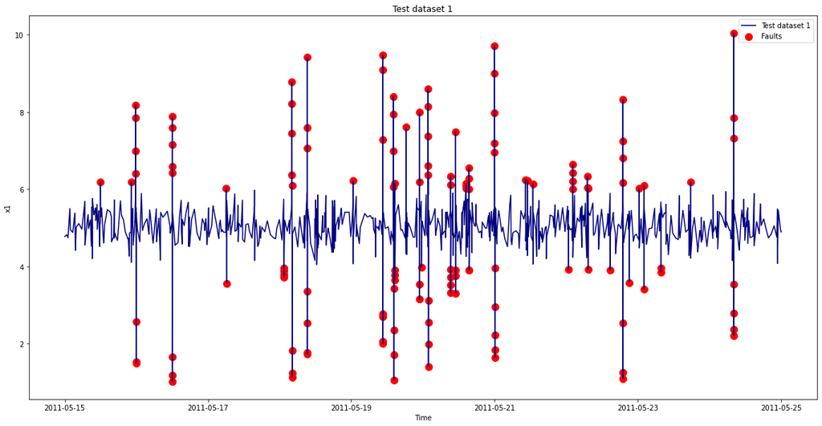

```python
plt.rcParams["figure.figsize"] = [20, 10]
plt.plot(df_test1['timestamp'], df_test1['x1'], label='Test dataset 1', color='navy')
plt.scatter(df_test1_faults['timestamp'], df_test1_faults['x1'], label='Faults', s=100, color='r')
plt.title('Test dataset 1')
plt.legend()
plt.ylabel('x1')
plt.xlabel('Time')
plt.show()
```

### Falhas do conjunto de dados de teste 2

**Nome do arquivo:** CONV_DATA_SET_3_REV_1_FAULTS.csv

**Descrição:** Dados de operação da coluna FCC coletados nos momentos de ocorrência de falhas de agarramento em sua válvula de controle de nível.

```python
df_test2_faults = pd.read_csv("datasets/original/CONV_DATA_SET_3_REV_1_FAULTS.csv", delimiter=";", header=0)
df_test2_faults.columns = ["timestamp", "x1", "x2", "x3", "x4", "x5", "x6", "x7", "x8", "x9", "x10", "x11", "x12", "x13", "x14", "x15", "x16", "x17"]
df_test2_faults["timestamp"] = pd.to_datetime(df_test2_faults["timestamp"], format='%d/%m/%Y %H:%M')
df_test2_faults["x7"] = df_test2_faults["x7"].astype(float)
df_test2_faults.head()
```

|  | timestamp | x1 | x2 | x3 | x4 | x5 | x6 | x7 | x8 | x9 | x10 | x11 | x12 | x13 | x14 | x15 | x16 | x17 |
| --- | --- | --- | --- | --- | --- | --- | --- | --- | --- | --- | --- | --- | --- | --- | --- | --- | --- | --- |
| 0 | 2012-04-01 10:50:00 | 3.982439 | 5.038079 | 41.696983 | 41.536659 | 0.768973 | 0.4 | 100.0 | 9179.009766 | 1000.121277 | 1.509862 | 1.192606 | 538.525452 | 538.608521 | 44.612244 | 271.095642 | 4553.051758 | 31.111778 |
| 1 | 2012-04-01 11:26:00 | 3.649686 | 5.038079 | 40.032520 | 41.523327 | 0.815463 | 0.4 | 100.0 | 9189.871094 | 1001.438110 | 1.509398 | 1.190955 | 538.555481 | 538.550415 | 44.382195 | 270.855865 | 4542.948730 | 31.131227 |
| 2 | 2012-04-01 15:43:00 | 6.118585 | 5.038079 | 42.546574 | 42.291100 | 0.737473 | 0.4 | 100.0 | 9206.459961 | 1002.422485 | 1.508898 | 1.196701 | 538.429260 | 538.609192 | 45.352222 | 270.512543 | 4573.750977 | 31.267668 |
| 3 | 2012-04-01 15:44:00 | 8.036281 | 5.038079 | 45.449226 | 42.278698 | 0.533266 | 0.4 | 100.0 | 9206.377930 | 1001.301758 | 1.508317 | 1.197113 | 538.426453 | 538.601624 | 45.410461 | 270.387573 | 4573.655762 | 31.267488 |
| 4 | 2012-04-01 15:45:00 | 2.609216 | 5.038079 | 40.870575 | 42.266300 | 0.711840 | 0.4 | 100.0 | 9206.295898 | 1002.076721 | 1.508097 | 1.197524 | 538.402588 | 538.594971 | 45.422588 | 270.450562 | 4573.560547 | 31.267309 |

```python
df_test2_faults.info()
```

```
<class 'pandas.core.frame.DataFrame'>
RangeIndex: 203 entries, 0 to 202
Data columns (total 18 columns):
 #   Column     Non-Null Count  Dtype
---  ------     --------------  -----
 0   timestamp  203 non-null    datetime64[ns]
 1   x1         203 non-null    float64
 2   x2         203 non-null    float64
 3   x3         203 non-null    float64
 4   x4         203 non-null    float64
 5   x5         203 non-null    float64
 6   x6         203 non-null    float64
 7   x7         203 non-null    float64
 8   x8         203 non-null    float64
 9   x9         203 non-null    float64
 10  x10        203 non-null    float64
 11  x11        203 non-null    float64
 12  x12        203 non-null    float64
 13  x13        203 non-null    float64
 14  x14        203 non-null    float64
 15  x15        203 non-null    float64
 16  x16        203 non-null    float64
 17  x17        203 non-null    float64
dtypes: datetime64[ns](1), float64(17)
memory usage: 28.7 KB
```

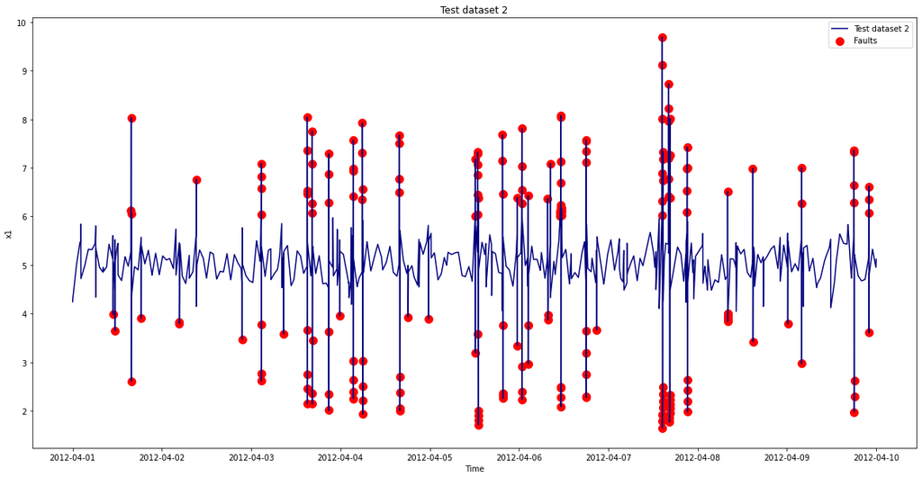

```python
plt.plot(df_test2['timestamp'], df_test2['x1'], label='Test dataset 2', color='navy')
plt.scatter(df_test2_faults['timestamp'], df_test2_faults['x1'], label='Faults', s=100, color='r')
plt.title('Test dataset 2')
plt.ylabel('x1')
plt.xlabel('Time')
plt.legend()
plt.show()
```

### Rotulagem dos dados

Rotulagem dos dados de acordo com a condição de operação:

- Operação normal: 0
- Operação com falha: 1

**Conjunto de dados de treinamento**

- Período sem ocorrência de falhas.

```python
df_train['fault'] = 0
df_train.describe()
```

|  | x1 | x2 | x3 | x4 | x5 | x6 | x7 | x8 | x9 | x10 | x11 | x12 | x13 | x14 | x15 | x16 | x17 | fault |
| --- | --- | --- | --- | --- | --- | --- | --- | --- | --- | --- | --- | --- | --- | --- | --- | --- | --- | --- |
| count | 20161.000000 | 2.016100e+04 | 20161.000000 | 20161.000000 | 20161.000000 | 2.016100e+04 | 20161.0 | 20161.000000 | 20161.000000 | 20161.000000 | 20161.000000 | 20161.000000 | 20161.000000 | 20161.000000 | 20161.000000 | 20161.000000 | 20161.000000 | 20161.0 |
| mean | 4.999847 | 5.008938e+00 | 27.234926 | 27.495736 | 0.964922 | 5.500001e-01 | 100.0 | 8118.782149 | 1352.047071 | 1.712521 | 1.201119 | 542.119941 | 542.120654 | 50.533945 | 320.497689 | 3934.083272 | 40.408948 | 0.0 |
| std | 0.259822 | 8.882004e-16 | 0.674935 | 0.661604 | 0.029507 | 2.220501e-16 | 0.0 | 512.514491 | 15.265609 | 0.013447 | 0.016811 | 0.707124 | 0.606936 | 1.575383 | 11.685267 | 127.480225 | 1.112471 | 0.0 |
| min | 3.930771 | 5.008938e+00 | 25.463827 | 25.849619 | 0.861468 | 5.500001e-01 | 100.0 | 7426.256836 | 1305.152100 | 1.675290 | 1.164233 | 539.825684 | 540.853821 | 46.608002 | 302.371002 | 3700.844482 | 38.483116 | 0.0 |
| 25% | 4.823519 | 5.008938e+00 | 26.784365 | 27.062254 | 0.943907 | 5.500001e-01 | 100.0 | 7639.987793 | 1341.665649 | 1.701806 | 1.188007 | 541.667481 | 541.721436 | 49.256180 | 309.235077 | 3815.947021 | 39.614120 | 0.0 |
| 50% | 5.007726 | 5.008938e+00 | 27.144409 | 27.430681 | 0.965749 | 5.500001e-01 | 100.0 | 7722.871094 | 1349.607422 | 1.712921 | 1.198062 | 542.099304 | 542.145019 | 50.501919 | 315.256317 | 3882.460938 | 40.110897 | 0.0 |
| 75% | 5.179343 | 5.008938e+00 | 27.539824 | 27.766863 | 0.986169 | 5.500001e-01 | 100.0 | 8671.154297 | 1359.909546 | 1.721852 | 1.211942 | 542.515747 | 542.335815 | 51.643265 | 332.883972 | 4064.233887 | 41.314793 | 0.0 |
| max | 5.779046 | 5.008938e+00 | 31.709133 | 30.784384 | 1.095330 | 5.500001e-01 | 100.0 | 8878.678711 | 1473.366943 | 1.756912 | 1.279220 | 544.969482 | 543.745850 | 56.716934 | 336.738403 | 4205.504883 | 43.154018 | 0.0 |

```python
df_train[df_train['fault'] == 1]
```

|  | timestamp | x1 | x2 | x3 | x4 | x5 | x6 | x7 | x8 | x9 | x10 | x11 | x12 | x13 | x14 | x15 | x16 | x17 | fault |
| --- | --- | --- | --- | --- | --- | --- | --- | --- | --- | --- | --- | --- | --- | --- | --- | --- | --- | --- | --- |

**Conjunto de dados de teste1**

- Período com ocorrência de falhas.

```python
df_test1['fault'] = 0
df_test1.loc[df_test1['timestamp'].isin(list(df_test1_faults['timestamp'])), 'fault'] = 1
df_test1.describe()
```

|  | x1 | x2 | x3 | x4 | x5 | x6 | x7 | x8 | x9 | x10 | x11 | x12 | x13 | x14 | x15 | x16 | x17 | fault |
| --- | --- | --- | --- | --- | --- | --- | --- | --- | --- | --- | --- | --- | --- | --- | --- | --- | --- | --- |
| count | 14401.000000 | 14401.0 | 14401.000000 | 14401.000000 | 14401.000000 | 1.440100e+04 | 14401.0 | 14401.000000 | 14401.000000 | 14401.000000 | 14401.000000 | 14401.000000 | 14401.000000 | 14401.000000 | 14401.000000 | 14401.000000 | 14401.000000 | 14401.000000 |
| mean | 5.041835 | 5.0 | 41.477955 | 41.811625 | 0.712661 | 4.000000e-01 | 100.0 | 9036.396338 | 1130.239716 | 1.615048 | 1.280824 | 534.242267 | 534.242675 | 48.028398 | 251.024437 | 4591.029125 | 31.397718 | 0.009513 |
| std | 0.362034 | 0.0 | 0.734107 | 0.659452 | 0.042880 | 5.551308e-17 | 0.0 | 153.204510 | 147.407481 | 0.005385 | 0.009701 | 0.569377 | 0.523367 | 1.079448 | 2.229698 | 52.156148 | 0.861090 | 0.097074 |
| min | 1.014221 | 5.0 | 38.689941 | 39.991123 | 0.235682 | 4.000000e-01 | 100.0 | 8508.570313 | 987.325867 | 1.598350 | 1.258520 | 532.229553 | 533.151916 | 44.380047 | 246.987717 | 4457.558105 | 28.000462 | 0.000000 |
| 25% | 4.843078 | 5.0 | 41.076622 | 41.419647 | 0.689443 | 4.000000e-01 | 100.0 | 8873.953125 | 1001.866150 | 1.610023 | 1.274694 | 533.766418 | 533.815369 | 47.310394 | 249.613480 | 4551.766602 | 31.115356 | 0.000000 |
| 50% | 5.027987 | 5.0 | 41.450523 | 41.776627 | 0.713562 | 4.000000e-01 | 100.0 | 9111.929688 | 1007.279541 | 1.614709 | 1.280297 | 534.417725 | 534.542908 | 48.040634 | 250.416061 | 4586.239258 | 31.539705 | 0.000000 |
| 75% | 5.248820 | 5.0 | 41.830826 | 42.138554 | 0.737288 | 4.000000e-01 | 100.0 | 9169.700195 | 1300.833740 | 1.620009 | 1.286066 | 534.701172 | 534.686646 | 48.768955 | 251.921906 | 4625.540039 | 31.807951 | 0.000000 |
| max | 10.044393 | 5.0 | 50.608631 | 45.103973 | 0.889228 | 4.000000e-01 | 100.0 | 9411.336914 | 1308.545044 | 1.631893 | 1.340867 | 536.089722 | 535.000000 | 53.115994 | 258.403687 | 4822.493164 | 33.390553 | 1.000000 |

```python
df_test1[df_test1['fault'] == 1]
```

|  | timestamp | x1 | x2 | x3 | x4 | x5 | x6 | x7 | x8 | x9 | x10 | x11 | x12 | x13 | x14 | x15 | x16 | x17 | fault |
| --- | --- | --- | --- | --- | --- | --- | --- | --- | --- | --- | --- | --- | --- | --- | --- | --- | --- | --- | --- |
| 719 | 2011-05-15 11:59:00 | 6.187165 | 5.0 | 41.421471 | 41.049580 | 0.720817 | 0.4 | 100.0 | 9152.883789 | 997.836670 | 1.617564 | 1.273867 | 534.681763 | 534.558228 | 48.558750 | 250.294266 | 4537.524902 | 31.576838 | 1 |
| 1335 | 2011-05-15 22:15:00 | 6.193666 | 5.0 | 41.715836 | 41.200577 | 0.674332 | 0.4 | 100.0 | 9125.679688 | 1004.610901 | 1.619547 | 1.277296 | 534.441528 | 534.605835 | 48.739979 | 250.559815 | 4552.662109 | 31.631004 | 1 |
| 1422 | 2011-05-15 23:42:00 | 6.412030 | 5.0 | 42.784664 | 41.862389 | 0.617861 | 0.4 | 100.0 | 9092.121094 | 1005.623047 | 1.620270 | 1.299449 | 534.811951 | 534.645569 | 49.435570 | 250.209671 | 4530.175781 | 31.650082 | 1 |
| 1423 | 2011-05-15 23:43:00 | 7.844289 | 5.0 | 45.971382 | 41.861183 | 0.351488 | 0.4 | 100.0 | 9107.522461 | 1000.590393 | 1.620789 | 1.299865 | 534.563538 | 534.643616 | 49.487431 | 250.447235 | 4539.993164 | 31.650370 | 1 |
| 1424 | 2011-05-15 23:44:00 | 8.187556 | 5.0 | 47.323505 | 41.859978 | 0.325430 | 0.4 | 100.0 | 9122.922852 | 1004.393005 | 1.620664 | 1.300281 | 534.397888 | 534.638916 | 49.576611 | 250.550095 | 4536.802734 | 31.650660 | 1 |
| ... | ... | ... | ... | ... | ... | ... | ... | ... | ... | ... | ... | ... | ... | ... | ... | ... | ... | ... | ... |
| 13443 | 2011-05-24 08:03:00 | 7.841220 | 5.0 | 48.083702 | 44.128143 | 0.439353 | 0.4 | 100.0 | 8895.154297 | 1300.204468 | 1.610325 | 1.283317 | 533.953003 | 533.924561 | 49.697388 | 251.956192 | 4574.598145 | 31.011583 | 1 |
| 13444 | 2011-05-24 08:04:00 | 2.210964 | 5.0 | 44.783012 | 44.224480 | 0.638675 | 0.4 | 100.0 | 8895.151367 | 1301.167603 | 1.608475 | 1.283417 | 533.855896 | 533.922180 | 49.707329 | 252.023346 | 4564.280273 | 31.015743 | 1 |
| 13445 | 2011-05-24 08:05:00 | 2.371205 | 5.0 | 41.573292 | 44.201832 | 0.673972 | 0.4 | 100.0 | 8895.148438 | 1302.073486 | 1.607465 | 1.283517 | 533.543152 | 533.917603 | 49.811756 | 251.966736 | 4575.876953 | 31.019903 | 1 |
| 13446 | 2011-05-24 08:06:00 | 2.779308 | 5.0 | 41.703892 | 44.155071 | 0.704856 | 0.4 | 100.0 | 8895.146484 | 1300.723755 | 1.610599 | 1.283617 | 533.291626 | 533.913696 | 50.016376 | 251.898865 | 4588.894043 | 31.024063 | 1 |
| 13447 | 2011-05-24 08:07:00 | 3.537409 | 5.0 | 42.042366 | 44.108315 | 0.713264 | 0.4 | 100.0 | 8895.143555 | 1300.870239 | 1.613844 | 1.283718 | 533.577881 | 533.910522 | 50.126549 | 251.750961 | 4584.513672 | 31.028223 | 1 |

137 rows × 19 columns

**Conjunto de dados de teste2**

```python
df_test2['fault'] = 0
df_test2.loc[df_test2['timestamp'].isin(list(df_test2_faults['timestamp'])), 'fault'] = 1
df_test2.describe()
```

|  | x1 | x2 | x3 | x4 | x5 | x6 | x7 | x8 | x9 | x10 | x11 | x12 | x13 | x14 | x15 | x16 | x17 | fault |
| --- | --- | --- | --- | --- | --- | --- | --- | --- | --- | --- | --- | --- | --- | --- | --- | --- | --- | --- |
| count | 12961.000000 | 1.296100e+04 | 12961.000000 | 12961.000000 | 12961.000000 | 12961.0 | 12961.0 | 12961.000000 | 12961.000000 | 12961.000000 | 12961.000000 | 12961.000000 | 12961.000000 | 12961.000000 | 12961.000000 | 12961.000000 | 12961.000000 | 12961.000000 |
| mean | 5.043308 | 5.038079e+00 | 41.968041 | 42.333295 | 0.706513 | 0.4 | 100.0 | 9180.569942 | 1000.193656 | 1.509002 | 1.203685 | 538.589946 | 538.590695 | 45.754904 | 264.379292 | 4657.914578 | 34.319287 | 0.015662 |
| std | 0.383548 | 8.882127e-16 | 0.855244 | 0.716608 | 0.052926 | 0.0 | 0.0 | 76.070730 | 4.086560 | 0.007101 | 0.009937 | 0.266503 | 0.101576 | 0.968137 | 4.781164 | 61.780632 | 5.708667 | 0.124170 |
| min | 1.637933 | 5.038079e+00 | 37.654346 | 40.521931 | 0.126434 | 0.4 | 100.0 | 7664.657715 | 925.182678 | 1.493867 | 1.176963 | 532.839600 | 538.204712 | 43.497082 | 251.361374 | 4527.202148 | 29.462337 | 0.000000 |
| 25% | 4.845560 | 5.038079e+00 | 41.590900 | 41.959515 | 0.681738 | 0.4 | 100.0 | 9148.041992 | 999.611755 | 1.501461 | 1.196945 | 538.449524 | 538.544983 | 45.045658 | 259.864105 | 4617.608887 | 31.141470 | 0.000000 |
| 50% | 5.046213 | 5.038079e+00 | 41.893272 | 42.244850 | 0.708872 | 0.4 | 100.0 | 9178.291992 | 1000.433472 | 1.509692 | 1.203349 | 538.590820 | 538.588074 | 45.676540 | 264.591858 | 4662.656738 | 31.793270 | 0.000000 |
| 75% | 5.242998 | 5.038079e+00 | 42.221920 | 42.577446 | 0.735720 | 0.4 | 100.0 | 9211.354492 | 1001.289612 | 1.511634 | 1.209123 | 538.727661 | 538.643799 | 46.483383 | 267.886688 | 4710.452148 | 33.382061 | 0.000000 |
| max | 9.693020 | 5.038079e+00 | 55.730022 | 54.933697 | 0.918962 | 0.4 | 100.0 | 10164.336910 | 1005.505676 | 1.539886 | 1.325265 | 543.156616 | 538.946350 | 50.256985 | 276.974091 | 4784.279297 | 48.148434 | 1.000000 |

```python
df_test2[df_test2['fault'] == 1]
```

|  | timestamp | x1 | x2 | x3 | x4 | x5 | x6 | x7 | x8 | x9 | x10 | x11 | x12 | x13 | x14 | x15 | x16 | x17 | fault |
| --- | --- | --- | --- | --- | --- | --- | --- | --- | --- | --- | --- | --- | --- | --- | --- | --- | --- | --- | --- |
| 650 | 2012-04-01 10:50:00 | 3.982439 | 5.038079 | 41.696983 | 41.536659 | 0.768973 | 0.4 | 100.0 | 9179.009766 | 1000.121277 | 1.509862 | 1.192606 | 538.525452 | 538.608521 | 44.612244 | 271.095642 | 4553.051758 | 31.111778 | 1 |
| 686 | 2012-04-01 11:26:00 | 3.649686 | 5.038079 | 40.032520 | 41.523327 | 0.815463 | 0.4 | 100.0 | 9189.871094 | 1001.438110 | 1.509398 | 1.190955 | 538.555481 | 538.550415 | 44.382195 | 270.855865 | 4542.948730 | 31.131227 | 1 |
| 943 | 2012-04-01 15:43:00 | 6.118585 | 5.038079 | 42.546574 | 42.291100 | 0.737473 | 0.4 | 100.0 | 9206.459961 | 1002.422485 | 1.508898 | 1.196701 | 538.429260 | 538.609192 | 45.352222 | 270.512543 | 4573.750977 | 31.267668 | 1 |
| 944 | 2012-04-01 15:44:00 | 8.036281 | 5.038079 | 45.449226 | 42.278698 | 0.533266 | 0.4 | 100.0 | 9206.377930 | 1001.301758 | 1.508317 | 1.197113 | 538.426453 | 538.601624 | 45.410461 | 270.387573 | 4573.655762 | 31.267488 | 1 |
| 945 | 2012-04-01 15:45:00 | 2.609216 | 5.038079 | 40.870575 | 42.266300 | 0.711840 | 0.4 | 100.0 | 9206.295898 | 1002.076721 | 1.508097 | 1.197524 | 538.402588 | 538.594971 | 45.422588 | 270.450562 | 4573.560547 | 31.267309 | 1 |
| ... | ... | ... | ... | ... | ... | ... | ... | ... | ... | ... | ... | ... | ... | ... | ... | ... | ... | ... | ... |
| 12607 | 2012-04-09 18:07:00 | 2.624392 | 5.038079 | 41.149113 | 43.886776 | 0.667695 | 0.4 | 100.0 | 9147.460938 | 1000.066833 | 1.505421 | 1.202345 | 538.135742 | 538.783142 | 46.374382 | 265.235748 | 4723.424316 | 44.752544 | 1 |
| 12840 | 2012-04-09 22:00:00 | 6.072597 | 5.038079 | 41.395084 | 41.790455 | 0.783695 | 0.4 | 100.0 | 9106.007813 | 999.617127 | 1.510468 | 1.209128 | 538.614380 | 538.683533 | 45.023827 | 264.591858 | 4728.319824 | 45.266800 | 1 |
| 12841 | 2012-04-09 22:01:00 | 6.345232 | 5.038079 | 42.116508 | 41.796139 | 0.690992 | 0.4 | 100.0 | 9132.655273 | 999.864746 | 1.509882 | 1.209183 | 538.568909 | 538.681580 | 45.049908 | 264.483215 | 4728.447266 | 45.269974 | 1 |
| 12842 | 2012-04-09 22:02:00 | 6.617867 | 5.038079 | 43.511612 | 41.801823 | 0.704497 | 0.4 | 100.0 | 9159.303711 | 998.745178 | 1.508751 | 1.209239 | 538.515503 | 538.682251 | 45.035690 | 264.488434 | 4728.574707 | 45.273148 | 1 |
| 12843 | 2012-04-09 22:03:00 | 3.607115 | 5.038079 | 40.543041 | 41.807510 | 0.723445 | 0.4 | 100.0 | 9177.125977 | 998.948914 | 1.509030 | 1.209294 | 538.335754 | 538.686218 | 45.100487 | 264.548737 | 4728.702148 | 45.276318 | 1 |

203 rows × 19 columns

# Conclusões

- Os conjuntos de dados não possuem dados faltantes.
- Poucos procedimentos de limpeza dos dados foram necessários, apenas correções de formato dos dados foram realizadas.
- A variável x1 deve ser utilizada para o treinamento de modelos para detecção da falha de agarramento na válvula de controle de nível da coluna FCC.
- As variáveis x3 e x5 possuem valores de correlação não nulos com relação à variável x1 nos conjuntos de dados de teste, e, portanto, podem possivelmente ser utilizadas junto da variável x1 para o treinamento de modelo de detecção da falha de agarramento.

# Exportação dos dados

```python
# df_train.to_csv('datasets/confidencial/df_train.csv', index=False)
# df_test1.to_csv('datasets/confidencial/df_test1.csv', index=False)
# df_test2.to_csv('datasets/confidencial/df_test2.csv', index=False)
```